# Handout Lecture 2: Randomization Inference

- Show All Code
- Hide All Code
- View Source

Author

Edward Vytlacil

Published

May 28, 2023

## Introduction

[Lecture 2](https://edward-vytlacil.github.io/Viax/PROGRESA_Presentation_Econ201.html#/title-slide) covered randomization inference and multiple hypothesis testing, and applied those methods to the PROGRESA data of Lab 1 ([slides](https://edward-vytlacil.github.io/Viax/PROGRESA_Presentation_Econ201.html), [handout](https://edward-vytlacil.github.io/Viax/PROGRESA_Handout_Econ201)). This handout goes through the code used in Lecture 2.

## Load Libraries

Start by loading the following libraries. Install them first if you have not already done so.

| Library | Purpose |
| --- | --- |
| `stargazer` | package by Hlavac (2022) for creating tables. Creates publication-ready tables that are especially well-suited for reporting results in the standard format for academic papers in economics and other s… |
| `ggplot2` | package by Wickham (2016) for creating figures. Is more complicated to use than the graphing options in base **R**, but much more powerful and flexible. |
| `ri2` | package by Coppock (2022) for conducting randomization inference. |

```r
# install packages if not already installed
install.packages("stargazer")
install.packages("ggplot2")
install.packages("ri2")
```

```r
# load packages (make sure they are already installed)
library(stargazer)
library(ggplot2)
library(ri2)
```

## Data

We load the PROGRESA data and prepare the data for analysis, following the same steps as in Lab 1. We will use the post data, and we name our data.frame `dfPost`.

```r
df_ <- read.csv("https://edward-vytlacil.github.io/Data/PROGRESA.csv",
          header=TRUE, sep=",") # read csv
df_$treat <- df_$progresa1
df_$girl <- df_$sex1
df<-subset(df_, wave==4 | wave==1,
           select= c(sooloca,sooind_id,age1,hgc1,school,treat,girl,wave))
rm(df_)
balanced_ids <- intersect(df[df$wave==4,"sooind_id"],
                  df[df$wave==1 & df$age1>=6 & df$age1<=16,"sooind_id"])
dfPost  <- df[df$wave==4 & df$sooind_id %in% balanced_ids,]
```

## Randomization Inference:

We use the package `ri2` to conduct randomization inference on the sharp null of no treatment effect for any individual. In the first step, we declare the randomization procedure, stating exactly how randomization was done. In this example, we are declaring that randomization was done at the village level, with all children within a given village randomized in or out based on whether their village was randomized in or out. In the data, there are 491 villages, of which 308 were treated. We thus declare that randomization was done at the village level, with any way to assign treatment to 308 out of 491 villages equally likely.

```r
n.0<- length(unique(dfPost$sooloca))
m.0<- length(unique(subset(dfPost,
          dfPost$treat==1)$sooloca))
declaration_ra<-declare_ra(N=n.0,
          m=m.0,clusters=dfPost$sooloca)
declaration_ra
```

**1**

`n.0` is the number of unique village id’s, thus the number of villages. In our data, `n.0` equals 491. Recall that `sooloca` is the village id number. [Lab 1 Handout](https://edward-vytlacil.github.io/Viax/PROGRESA_Handout_Econ201#number-of-observations) covers the use of the `length` and `unique` functions.

**2**

`m.0` is the number of unique village id’s in treated sample, thus the number of treated villages. In our data, `m.0` equals 308.

**3**

Using `declare_ra` with option `clusters=dfPost$sooloca` from package `ri2` to declare that randomization was done at the village level (clustering at village level), with each of the ways to assign treatment to `m.0` out of `n.0` villages equally likely.

**4**

The code returns the following output, where “units” are observations (children, because each row in the data.frame is a child), “clusters” are villages (because we used option `clusters=dfPost$sooloca` where `sooloca` is village id), and the probability of being assigned to treatment is $m.0/n.0 = 308/491 = 0.6272912$.

```
Random assignment procedure: Cluster random assignment
Number of units: 14996
Number of clusters: 491
Number of treatment arms: 2
The possible treatment categories are 0 and 1.
The number of possible random assignments is approximately infinite.
The probabilities of assignment are constant across units:
   prob_0    prob_1
0.3727088 0.6272912
```

Having declared our randomization procedure, we now use the function `conduct_ri` from package `ri2` to conduct the randomization inference. Because there are “approximately infinite” number of possible ways to assign treatment to $308$ out of $491$ villages, we will randomly sample from such ways to assign treatment.

```r
# perform randomization inference
ri_out <-  conduct_ri(
    test_function = function(d){
       abs(mean(d[d$treat==1,]$school)
         -mean(d[d$treat==0,]$school))},
    declaration = declaration_ra,
    assignment = "treat",
    outcome = "school",
    data = dfPost,
    sims = 10000
  )
```

**1**

We are using the function `conduct_ri` from package `ri2`, and saving the results as `ri_out`.

**2**

We are defining the test statistic, called here the `test_function`. The function takes as an input a data.frame (here denoted `d`, which will be whatever data.frame is used to compute the test statistic). The test statistic is being defined as $T_N = | \bar{Y}_1 - \bar{Y}_0|$, where $\bar{Y}_1$ is the sample mean of school enrollment among treated observations, and $\bar{Y}_0$ is the sample mean of school enrollment among control observations.

**3**

We are declaring the randomization procedure, using the saved object from our `declare_ra` function in the first step.

**4**

Our treatment variable is assignment to PROGRESA, which is `treat` in our data.

**5**

Our outcome variable (our $Y$ variable) is school enrollment, which is `school` in our data.

**6**

Use our data.frame `dfPost` as data.

**7**

We cannot use all the ${491 \choose 308}$ possible ways to assign treatment to 308 out of 491 villages. Instead, we are randomly sampling $10,000$ such ways to assign treatment.

We have saved the output from our randomization inference as `ri_out`. We can now print the summary of the results, and plot the figure illustrating the results.

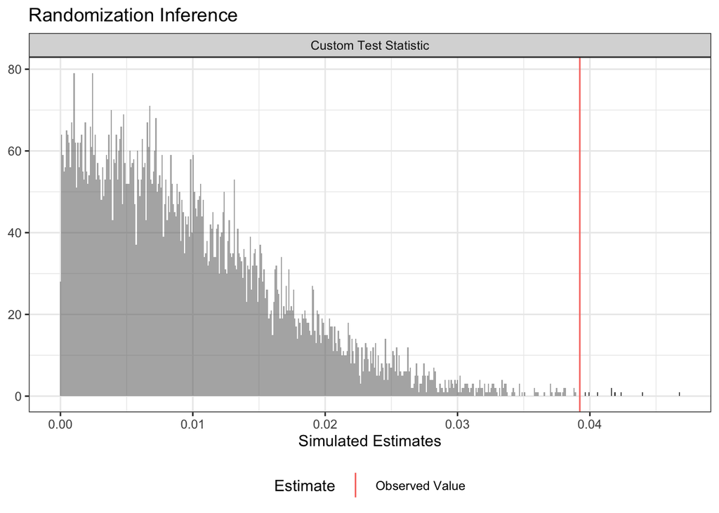

```r
# showing results
plot(ri_out)
```

```r
summary(ri_out)
```

```
                   term   estimate two_tailed_p_value
1 Custom Test Statistic 0.03923947              9e-04
```

## Randomization Inference for Subgroups

In [Lecture 2](https://edward-vytlacil.github.io/Viax/PROGRESA_Presentation_Econ201.html#/title-slide), we also applied randomization inference separately for subgroups, for example, by sex and highest grade completed at baseline. Doing so is valid as treatment does not effect baseline characteristics, and thus it is valid to do inference within subgroups defined by those baseline characteristics. To implement randomization inference by sex and highest grade completed at baseline (for a total of $2 \times 10 = 20$ subgroups), we could copy and paste our previous code $20$ times, and modify each instance of the code to use a different data.frame (for example, subset of data for boys in grade $1$, separately girls in grade $1$, and so forth). It would be tedious to write the code that way, tedious for others to read the resulting code, and the code would be prone to errors. Instead, we create a user defined function to make the code more elegant and easier to read and debug.

```r
f.ri <- function(d){

n.0<- length(unique(d$sooloca))
m.0<- length(unique(subset(d,d$treat==1)$sooloca))

declaration_ra<-declare_ra(N=n.0,m=m.0,clusters=d$sooloca)

ri_out <-  conduct_ri(
     test_function =
      function(d){with(d, abs(mean(d[treat==1,]$school) - mean(d[treat==0,]$school)))},
    declaration = declaration_ra,
    assignment = "treat",
      outcome = "school",
    data = d,
    sims = 10000
  )
return(ri_out)
  }
ri.bysexgrade <- by(dfPost, list(dfPost$girl,dfPost$hgc1),f.ri)
```

**1**

Defining function `f.ri` that performs our randomization procedure on the inputted data frame.

**2**

Using `by` to apply our function `f.ri` separately by sex and highest grade completed. `by` is similar to `tapply`, see `?by` for help on `by`. We are saving the results in an object we named `ri.bysexgrade`.

We can now examine the results of our saved object `ri.bysexgrade`. In the saved object, `ri.bysexgrade[[g,j]]` are the saved results for `girl==g` (where `g=1` is boys and `g=2` is girls) and `hgc1==j`. For example, to see the plot of the results for the sharp null of no effect for boys in third grade:

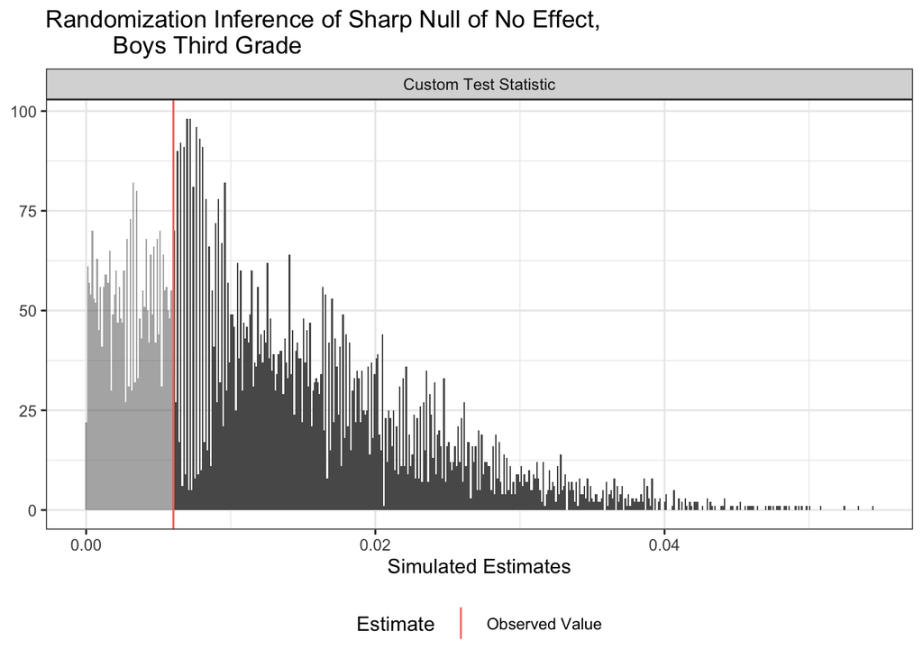

```r
plot(ri.bysexgrade[[1,3]]) +
  ggtitle("Randomization Inference of Sharp Null of No Effect,
          Boys Third Grade")
```

or for the null of no effect for girls in seventh grade:

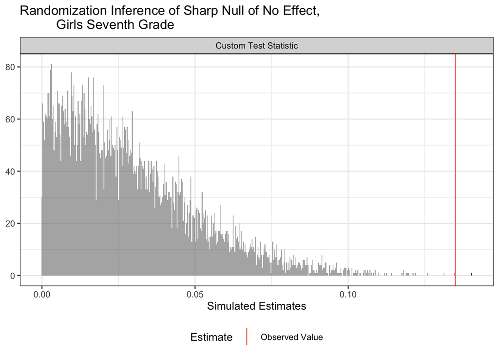

```r
plot(ri.bysexgrade[[2,7]]) +
  ggtitle("Randomization Inference of Sharp Null of No Effect,
          Girls Seventh Grade")
```

In [Lecture 2](https://edward-vytlacil.github.io/Viax/PROGRESA_Presentation_Econ201.html#/title-slide), we reported a table of the randomization-inference p-values from this saved object. We used the following code:

**Testing Sharp Null**

| Grade | p-values boys | p-values girls |
| --- | --- | --- |
| 1 | 0.347 | 0.619 |
| 2 | 0.008 | 0.930 |
| 3 | 0.710 | 0.349 |
| 4 | 0 | 0.026 |
| 5 | 0.299 | 0.075 |
| 6 | 0.002 | 0.007 |
| 7 | 0.010 | 0.0001 |
| 8 | 0.557 | 0.630 |
| 9 | 0.280 | 0.681 |
| 10 | 0.258 | 0.657 |

```r
pvalues.boys <- sapply(1:10,function(j){
    summary(ri.bysexgrade[[1,j]])$two_tailed_p_value} )
pvalues.girls <- sapply(1:10,function(j){
    summary(ri.bysexgrade[[2,j]])$two_tailed_p_value} )
results.p<-cbind(1:10,pvalues.boys,pvalues.girls)
results.names <- c("Grade","p-values boys","p-values girls")
colnames(results.p)<-results.names
stargazer(results.p,  digits=3, type="html",
          title="Testing Sharp Null")
```

**1**

`summary(ri.bysexgrade[[1,j]])$two_tailed_p_value` gives the p-value for boys in grade $j$. By using `sapply`, we are extracting the p-values for boys in each grade from $1$ to $10$, and saving the resulting p-values in the vector `pvalues.boys`.

**2**

`summary(ri.bysexgrade[[2,j]])$two_tailed_p_value` gives the p-value for girls in grade $j$. By using `sapply`, we are extracting the p-values for boys in each grade from $1$ to $10$, and saving the resulting p-values in the vector `pvalues.girls`.

**3**

Creating a matrix, named `results.p`, where the first column are the numbers $1,2,...,10$, the second column are the p-values for boys, and the third column are the p-vlaues for girls.

**4**

Labeling the columns of the matrix `results.p`.

**5**

Using stargazer to produce the table of p-values.

## Multiple Hypothesis Testing

In [Lecture 2](https://edward-vytlacil.github.io/Viax/PROGRESA_Presentation_Econ201.html#/title-slide), we also saw how to correct a vector of p-values for multiple hypothesis testing. Consider the p-values for boys, `pvalues.boys`.

```r
pvalues.boys
```

```
 [1] 0.3469 0.0084 0.7100 0.0000 0.2989 0.0019 0.0104 0.5575 0.2803 0.2582
```

Each element of `pvalues.boys` is the p-value for a different null hypothesis. For example, the first element of `pvalues.boys`, 0.3469, is the p-value for the sharp null of no effect for boys in first grade, while the second element of `pvalues.boys`, 0.0084, is the p-value for the sharp null of no effect for boys in second grade. We can correct this vector for multiple hypothesis testing using the function `p.adjust` with option `method="bonferroni"`:

```r
p.adjust(pvalues.boys, method="bonferroni")
```

```
 [1] 1.000 0.084 1.000 0.000 1.000 0.019 0.104 1.000 1.000 1.000
```

or (better) with option `method="holm"`:

```r
p.adjust(pvalues.boys, method="holm")
```

```
 [1] 1.0000 0.0672 1.0000 0.0000 1.0000 0.0171 0.0728 1.0000 1.0000 1.0000
```

In [Lecture 2](https://edward-vytlacil.github.io/Viax/PROGRESA_Presentation_Econ201.html#/title-slide), we used the following code to make a `stargazer` table of the resulting p-values.

**Boys**

|  | Uncorrected | Bonferroni | Holm’s |
| --- | --- | --- | --- |
| 1 | 0.347 | 1 | 1 |
| 2 | 0.008 | 0.084 | 0.067 |
| 3 | 0.710 | 1 | 1 |
| 4 | 0 | 0 | 0 |
| 5 | 0.299 | 1 | 1 |
| 6 | 0.002 | 0.019 | 0.017 |
| 7 | 0.010 | 0.104 | 0.073 |
| 8 | 0.557 | 1 | 1 |
| 9 | 0.280 | 1 | 1 |
| 10 | 0.258 | 1 | 1 |

**Girls**

|  | Uncorrected | Bonferroni | Holm’s |
| --- | --- | --- | --- |
| 1 | 0.619 | 1 | 1 |
| 2 | 0.930 | 1 | 1 |
| 3 | 0.349 | 1 | 1 |
| 4 | 0.026 | 0.265 | 0.212 |
| 5 | 0.075 | 0.747 | 0.523 |
| 6 | 0.007 | 0.072 | 0.065 |
| 7 | 0.0001 | 0.001 | 0.001 |
| 8 | 0.630 | 1 | 1 |
| 9 | 0.681 | 1 | 1 |
| 10 | 0.657 | 1 | 1 |

```r
f.adjust <- function(x){
  results.p<-cbind(x,p.adjust(x, method=c("bonferroni")),
                   p.adjust(x, method=c("holm")))
  colnames(results.p)<-c("Uncorrected","Bonferroni","Holm's")
  rownames(results.p)<-c(1:nrow(x))
  return(results.p)
   }
stargazer(f.adjust(pvalues.boys), type = "html", digits=3,
          title="Boys")
stargazer(f.adjust(pvalues.girls), type = "html", digits=3,
          title="Girls")
```

**1**

Defining a function `f.adjust`. The function takes as an input a vector of p-values, and computes the corresponding Bonferroni- and Holm-corrected p-values. It creates a matrix where the first column is the uncorrected p-values, and the second and third columns are the corrected p-values. It labels the matrix and then returns the matrix.

**2**

Applying the function `f.adjust` to the p-values for boys, and inputting the results into a `stargazer` table.

**3**

Applying the function `f.adjust` to the p-values for girls, and inputting the results into a `stargazer` table.

## References

Coppock, Alexander. 2022. “Ri2: Randomization Inference for Randomized Experiments.” https://https://CRAN.R-project.org/package=ri2.

Hlavac, Marek. 2022. “Stargazer: LaTeX Code and ASCII Text for Well-Formatted Regression and Summary Statistics Tables” R package version 5.2.3. https://CRAN.R-project.org/package=stargazer.

Wickham, Hadley. 2016. *Ggplot2: Elegant Graphics for Data Analysis*. Springer-Verlag New York. https://ggplot2.tidyverse.org.